# Moneyball Notebook

Let us see what Paul DePodesta did with all the previous years data: The dataset consists of 420 observations of 17 variables consisting of: Team = Name of team, League = American or National league, Year ( from 1999 to 2012), Games = Number of games played by each team in that year, W = Number of wins, RS = Runs scored, RA = Runs against, OBP = On base percentage, SLG = Slugging percentage, BA = Batting Average, OPS = On base plus slugging, OOBP = Opposition on base percentage, OSLG = Opposition slugging percentage, OOPS = Opposition on base plus slugging, Playoffs = 1 if teams makes playoff and 0 otherwise, RankSeason = Rank in season, RankPlayoffs = Rank in playoffs.

Let us read the data:

```r
baseball <- read.csv("baseball.csv")
str(baseball)
```

```
'data.frame':   420 obs. of  17 variables:
 $ Team        : chr  "ARI" "ATL" "BAL" "BOS" ...
 $ League      : chr  "NL" "NL" "AL" "AL" ...
 $ Year        : int  2012 2012 2012 2012 2012 2012 2012 2012 2012 2012 ...
 $ Games       : int  162 162 162 162 162 162 162 162 162 162 ...
 $ W           : int  81 94 93 69 61 85 97 68 64 88 ...
 $ RS          : int  734 700 712 734 613 748 669 667 758 726 ...
 $ RA          : int  688 600 705 806 759 676 588 845 890 670 ...
 $ OBP         : num  0.328 0.32 0.311 0.315 0.302 0.318 0.315 0.324 0.33 0.335 ...
 $ SLG         : num  0.418 0.389 0.417 0.415 0.378 0.422 0.411 0.381 0.436 0.422 ...
 $ BA          : num  0.259 0.247 0.247 0.26 0.24 0.255 0.251 0.251 0.274 0.268 ...
 $ OPS         : num  0.746 0.709 0.728 0.73 0.68 0.74 0.726 0.705 0.766 0.757 ...
 $ OOBP        : num  0.317 0.306 0.315 0.331 0.335 0.319 0.305 0.336 0.357 0.314 ...
 $ OSLG        : num  0.415 0.378 0.403 0.428 0.424 0.405 0.39 0.43 0.47 0.402 ...
 $ OOPS        : num  0.732 0.684 0.718 0.759 0.759 0.724 0.695 0.766 0.827 0.716 ...
 $ Playoffs    : int  0 1 1 0 0 0 1 0 0 1 ...
 $ RankSeason  : int  NA 4 5 NA NA NA 2 NA NA 6 ...
 $ RankPlayoffs: int  NA 5 4 NA NA NA 4 NA NA 2 ...
```

```r
summary(baseball)
```

```
     Team              League               Year          Games             W                RS               RA
 Length:420         Length:420         Min.   :1999   Min.   :161.0   Min.   : 43.00   Min.   : 513.0   Min.   : 529.0
 Class :character   Class :character   1st Qu.:2002   1st Qu.:162.0   1st Qu.: 72.00   1st Qu.: 706.0   1st Qu.: 697.0
 Mode  :character   Mode  :character   Median :2006   Median :162.0   Median : 81.00   Median : 752.5   Median : 754.5
                                       Mean   :2006   Mean   :161.9   Mean   : 80.96   Mean   : 759.5   Mean   : 759.5
                                       3rd Qu.:2009   3rd Qu.:162.0   3rd Qu.: 90.00   3rd Qu.: 813.0   3rd Qu.: 823.5
                                       Max.   :2012   Max.   :163.0   Max.   :116.00   Max.   :1009.0   Max.   :1028.0

      OBP              SLG               BA              OPS             OOBP             OSLG             OOPS
 Min.   :0.2920   Min.   :0.3390   Min.   :0.2330   Min.   :0.637   Min.   :0.2940   Min.   :0.3460   Min.   :0.6460
 1st Qu.:0.3220   1st Qu.:0.4017   1st Qu.:0.2560   1st Qu.:0.725   1st Qu.:0.3210   1st Qu.:0.4010   1st Qu.:0.7228
 Median :0.3320   Median :0.4200   Median :0.2630   Median :0.752   Median :0.3310   Median :0.4190   Median :0.7515
 Mean   :0.3323   Mean   :0.4197   Mean   :0.2636   Mean   :0.752   Mean   :0.3323   Mean   :0.4197   Mean   :0.7520
 3rd Qu.:0.3410   3rd Qu.:0.4370   3rd Qu.:0.2710   3rd Qu.:0.778   3rd Qu.:0.3430   3rd Qu.:0.4380   3rd Qu.:0.7800
 Max.   :0.3730   Max.   :0.4910   Max.   :0.2940   Max.   :0.851   Max.   :0.3840   Max.   :0.4990   Max.   :0.8830

    Playoffs        RankSeason     RankPlayoffs
 Min.   :0.0000   Min.   :1.000   Min.   :1.000
 1st Qu.:0.0000   1st Qu.:2.000   1st Qu.:3.000
 Median :0.0000   Median :4.000   Median :4.000
 Mean   :0.2714   Mean   :3.649   Mean   :3.158
 3rd Qu.:1.0000   3rd Qu.:5.000   3rd Qu.:4.000
 Max.   :1.0000   Max.   :7.000   Max.   :5.000
                  NA's   :306     NA's   :306
```

Paul DePodesta reduced the planning problem for the upcoming season to a mathematics problem based on the information before 2002.

Question that motivated him: What would it take to make team A crossing the playoffs?

```r
# year < 2002 because we are predicting for the year 2002 based on values from before 2002
baseball2002 <- subset(baseball, Year < 2002)
str(baseball2002)
```

```
'data.frame':   90 obs. of  17 variables:
 $ Team        : chr  "ANA" "ARI" "ATL" "BAL" ...
 $ League      : chr  "AL" "NL" "NL" "AL" ...
 $ Year        : int  2001 2001 2001 2001 2001 2001 2001 2001 2001 2001 ...
 $ Games       : int  162 162 162 162 161 162 162 162 162 162 ...
 $ W           : int  75 92 88 63 82 88 83 66 91 73 ...
 $ RS          : int  691 818 729 687 772 777 798 735 897 923 ...
 $ RA          : int  730 677 643 829 745 701 795 850 821 906 ...
 $ OBP         : num  0.327 0.341 0.324 0.319 0.334 0.336 0.334 0.324 0.35 0.354 ...
 $ SLG         : num  0.405 0.442 0.412 0.38 0.439 0.43 0.451 0.419 0.458 0.483 ...
 $ BA          : num  0.261 0.267 0.26 0.248 0.266 0.261 0.268 0.262 0.278 0.292 ...
 $ OPS         : num  0.732 0.783 0.736 0.699 0.773 0.766 0.785 0.743 0.808 0.837 ...
 $ OOBP        : num  0.331 0.311 0.314 0.337 0.329 0.321 0.334 0.341 0.341 0.35 ...
 $ OSLG        : num  0.412 0.404 0.384 0.439 0.393 0.398 0.427 0.455 0.417 0.48 ...
 $ OOPS        : num  0.743 0.715 0.698 0.776 0.722 0.719 0.761 0.796 0.758 0.83 ...
 $ Playoffs    : int  0 1 1 0 0 0 0 0 1 0 ...
 $ RankSeason  : int  NA 5 7 NA NA NA NA NA 6 NA ...
 $ RankPlayoffs: int  NA 1 3 NA NA NA NA NA 4 NA ...
```

```r
summary(baseball2002)
```

```
     Team              League               Year          Games             W                RS               RA
 Length:90          Length:90          Min.   :1999   Min.   :161.0   Min.   : 62.00   Min.   : 642.0   Min.   : 627.0
 Class :character   Class :character   1st Qu.:1999   1st Qu.:162.0   1st Qu.: 71.25   1st Qu.: 746.2   1st Qu.: 745.0
 Mode  :character   Mode  :character   Median :2000   Median :162.0   Median : 79.50   Median : 801.5   Median : 815.5
                                       Mean   :2000   Mean   :161.9   Mean   : 80.92   Mean   : 809.6   Mean   : 809.6
                                       3rd Qu.:2001   3rd Qu.:162.0   3rd Qu.: 90.75   3rd Qu.: 869.5   3rd Qu.: 867.2
                                       Max.   :2001   Max.   :163.0   Max.   :116.00   Max.   :1009.0   Max.   :1028.0

      OBP              SLG               BA              OPS              OOBP             OSLG             OOPS
 Min.   :0.3130   Min.   :0.3800   Min.   :0.2460   Min.   :0.6990   Min.   :0.3010   Min.   :0.3770   Min.   :0.6790
 1st Qu.:0.3290   1st Qu.:0.4153   1st Qu.:0.2610   1st Qu.:0.7452   1st Qu.:0.3290   1st Qu.:0.4160   1st Qu.:0.7492
 Median :0.3410   Median :0.4315   Median :0.2670   Median :0.7740   Median :0.3420   Median :0.4325   Median :0.7755
 Mean   :0.3405   Mean   :0.4324   Mean   :0.2684   Mean   :0.7728   Mean   :0.3405   Mean   :0.4325   Mean   :0.7730
 3rd Qu.:0.3518   3rd Qu.:0.4507   3rd Qu.:0.2765   3rd Qu.:0.8007   3rd Qu.:0.3500   3rd Qu.:0.4507   3rd Qu.:0.8000
 Max.   :0.3730   Max.   :0.4830   Max.   :0.2940   Max.   :0.8400   Max.   :0.3840   Max.   :0.4990   Max.   :0.8830

    Playoffs        RankSeason    RankPlayoffs
 Min.   :0.0000   Min.   :1.00   Min.   :1.000
 1st Qu.:0.0000   1st Qu.:2.00   1st Qu.:2.750
 Median :0.0000   Median :4.00   Median :3.500
 Mean   :0.2667   Mean   :3.50   Mean   :3.125
 3rd Qu.:1.0000   3rd Qu.:4.25   3rd Qu.:4.000
 Max.   :1.0000   Max.   :7.00   Max.   :4.000
                  NA's   :66     NA's   :66
```

How many games are needed to be won to make playoffs?

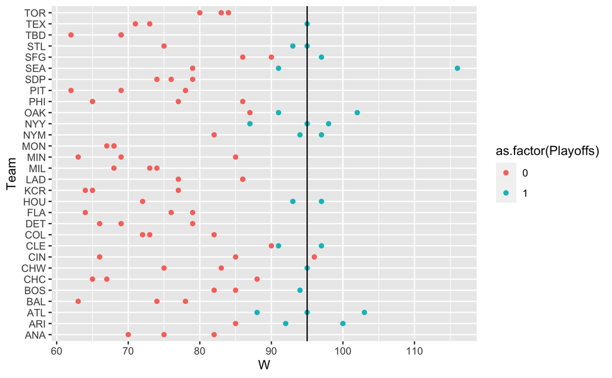

```r
library(ggplot2)
# question to answer: how many games are needed to make it to the playoffs?
ggplot(data = baseball2002, aes(x = W, y = Team, color = as.factor(Playoffs))) + geom_point() + geom_vline(xintercept = 95)
```

```r
NA
NA
```

Paul De Podesta judged that it would take around 95 games to make it to playoffs. If they won 95 games and still could not make it to playoffs, then that was just bad luck.

So how many runs needed to be scored for and against to win so many games?

Bill James, the founder of sabermetrics had earlier noticed that over time, there was a fairly stable relationship between the total runs difference in a season for a team (for-against) and the number of wins are important factors.

Justify Bill’s claim.

```r
baseball2002$run_diff <- baseball2002$RS - baseball2002$RA
linear_model <- lm(formula = W ~ run_diff, data = baseball2002)
summary(linear_model)
```

```
Call:
lm(formula = W ~ run_diff, data = baseball2002)

Residuals:
     Min       1Q   Median       3Q      Max
-10.4749  -2.2087   0.3369   2.3860   8.1203

Coefficients:
             Estimate Std. Error t value Pr(>|t|)
(Intercept) 80.922222   0.374248  216.23   <2e-16 ***
run_diff     0.099190   0.003323   29.85   <2e-16 ***
---
Signif. codes:  0 ‘***’ 0.001 ‘**’ 0.01 ‘*’ 0.05 ‘.’ 0.1 ‘ ’ 1

Residual standard error: 3.55 on 88 degrees of freedom
Multiple R-squared:  0.9101,    Adjusted R-squared:  0.9091
F-statistic:   891 on 1 and 88 DF,  p-value: < 2.2e-16
```

```r
ggplot(data = baseball2002, aes(x = run_diff, y = W)) + geom_point() + geom_smooth(method = "lm") + se=T
```

```
Error in ggplot(data = baseball2002, aes(x = run_diff, y = W)) + geom_point() +  :
  could not find function "+<-"
```

To get to playoffs, how much run differences are needed to ensure 95 wins?

How similar are slugging percentage and on-base percentage these two variables?

```r
summary(baseball$BA)
```

```
   Min. 1st Qu.  Median    Mean 3rd Qu.    Max.
 0.2330  0.2560  0.2630  0.2636  0.2710  0.2940
```

```r
summary(baseball$OBP)
```

```
   Min. 1st Qu.  Median    Mean 3rd Qu.    Max.
 0.2920  0.3220  0.3320  0.3323  0.3410  0.3730
```

```r
summary(baseball$SLG)
```

```
   Min. 1st Qu.  Median    Mean 3rd Qu.    Max.
 0.3390  0.4017  0.4200  0.4197  0.4370  0.4910
```

```r
summary(baseball$OPS)
```

```
   Min. 1st Qu.  Median    Mean 3rd Qu.    Max.
  0.637   0.725   0.752   0.752   0.778   0.851
```

Linear regression models: Predicting runs scored from OBP, SLG, BA and OPS separately.

```r
obp_model <- lm(formula = RS ~ OBP, data = baseball2002)
summary(obp_model)
```

```
Call:
lm(formula = RS ~ OBP, data = baseball2002)

Residuals:
    Min      1Q  Median      3Q     Max
-79.492 -20.333  -0.272  22.810  83.676

Coefficients:
            Estimate Std. Error t value Pr(>|t|)
(Intercept) -1046.80      85.91  -12.19   <2e-16 ***
OBP          5452.59     252.13   21.63   <2e-16 ***
---
Signif. codes:  0 ‘***’ 0.001 ‘**’ 0.01 ‘*’ 0.05 ‘.’ 0.1 ‘ ’ 1

Residual standard error: 32.75 on 88 degrees of freedom
Multiple R-squared:  0.8416,    Adjusted R-squared:  0.8398
F-statistic: 467.7 on 1 and 88 DF,  p-value: < 2.2e-16
```

```r
slg_model <- lm(formula = RS ~ SLG, data = baseball2002)
summary(slg_model)
```

```
Call:
lm(formula = RS ~ SLG, data = baseball2002)

Residuals:
    Min      1Q  Median      3Q     Max
-93.368 -25.082  -0.904  20.041  99.113

Coefficients:
            Estimate Std. Error t value Pr(>|t|)
(Intercept)  -442.85      74.54  -5.941 5.55e-08 ***
SLG          2896.65     172.12  16.829  < 2e-16 ***
---
Signif. codes:  0 ‘***’ 0.001 ‘**’ 0.01 ‘*’ 0.05 ‘.’ 0.1 ‘ ’ 1

Residual standard error: 40.07 on 88 degrees of freedom
Multiple R-squared:  0.7629,    Adjusted R-squared:  0.7603
F-statistic: 283.2 on 1 and 88 DF,  p-value: < 2.2e-16
```

```r
ba_model <- lm(formula = RS ~ BA, data = baseball2002)
summary(ba_model)
```

```
Call:
lm(formula = RS ~ BA, data = baseball2002)

Residuals:
    Min      1Q  Median      3Q     Max
-97.397 -29.208  -3.644  27.924 139.192

Coefficients:
            Estimate Std. Error t value Pr(>|t|)
(Intercept)   -778.9      120.6  -6.457 5.67e-09 ***
BA            5917.7      449.0  13.180  < 2e-16 ***
---
Signif. codes:  0 ‘***’ 0.001 ‘**’ 0.01 ‘*’ 0.05 ‘.’ 0.1 ‘ ’ 1

Residual standard error: 47.72 on 88 degrees of freedom
Multiple R-squared:  0.6638,    Adjusted R-squared:  0.6599
F-statistic: 173.7 on 1 and 88 DF,  p-value: < 2.2e-16
```

```r
ops_model <- lm(formula = RS ~ OPS, data = baseball2002)
summary(ops_model)
```

```
Call:
lm(formula = RS ~ OPS, data = baseball2002)

Residuals:
    Min      1Q  Median      3Q     Max
-73.074 -14.971  -4.293  12.801  69.052

Coefficients:
            Estimate Std. Error t value Pr(>|t|)
(Intercept)  -846.05      60.54  -13.98   <2e-16 ***
OPS          2142.30      78.25   27.38   <2e-16 ***
---
Signif. codes:  0 ‘***’ 0.001 ‘**’ 0.01 ‘*’ 0.05 ‘.’ 0.1 ‘ ’ 1

Residual standard error: 26.68 on 88 degrees of freedom
Multiple R-squared:  0.8949,    Adjusted R-squared:  0.8937
F-statistic: 749.6 on 1 and 88 DF,  p-value: < 2.2e-16
```

What happens if we combine `OBP` and `SLG` as regressors/predictors?:

```r
obp_slg_model <- lm(formula = RS ~ OBP + SLG, data = baseball2002)
summary(obp_slg_model)
```

```
Call:
lm(formula = RS ~ OBP + SLG, data = baseball2002)

Residuals:
    Min      1Q  Median      3Q     Max
-55.103 -14.808  -3.214  15.314  59.898

Coefficients:
            Estimate Std. Error t value Pr(>|t|)
(Intercept) -1014.02      60.76 -16.688  < 2e-16 ***
OBP          3562.39     267.63  13.311  < 2e-16 ***
SLG          1412.57     149.33   9.459 5.15e-15 ***
---
Signif. codes:  0 ‘***’ 0.001 ‘**’ 0.01 ‘*’ 0.05 ‘.’ 0.1 ‘ ’ 1

Residual standard error: 23.13 on 87 degrees of freedom
Multiple R-squared:  0.9219,    Adjusted R-squared:  0.9201
F-statistic: 513.7 on 2 and 87 DF,  p-value: < 2.2e-16
```

Add to that `BA` (A reason behind that*):

```r
obp_slg_ba_model <- lm(formula = RS ~ OBP + SLG + BA, data = baseball2002)
summary(obp_slg_ba_model)
```

```
Call:
lm(formula = RS ~ OBP + SLG + BA, data = baseball2002)

Residuals:
    Min      1Q  Median      3Q     Max
-53.180 -14.777  -3.514  16.035  58.865

Coefficients:
            Estimate Std. Error t value Pr(>|t|)
(Intercept) -1026.15      64.37 -15.941  < 2e-16 ***
OBP          3466.89     313.72  11.051  < 2e-16 ***
SLG          1369.05     167.09   8.193 2.15e-12 ***
BA            236.43     401.08   0.589    0.557
---
Signif. codes:  0 ‘***’ 0.001 ‘**’ 0.01 ‘*’ 0.05 ‘.’ 0.1 ‘ ’ 1

Residual standard error: 23.21 on 86 degrees of freedom
Multiple R-squared:  0.9222,    Adjusted R-squared:  0.9195
F-statistic:   340 on 3 and 86 DF,  p-value: < 2.2e-16
```

Explain the result and which model you may choose. Based on the combined model, BA variable is not significant compared to other predictors (OBP and SLG)

What about for opposition performance? By opposition we mean the total run defended by that particular team in whole season.

At the start of 2002, the team OBP = 0.339 and SLG = 0.43 based on player statistics. Predict how many runs will be scored from above information.

In the book, Paul De Podesta predicted it to be between 800 and 820.

Similarly using opposition statistics, they estimated OOBP = 0.307 and OOSLG = 0.373. How do you predict the number of wins?

How do you predict RD?

```r
# RD_pred<- RS_pred-RA_pred
RD_pred = RS
```

In the book, Paul De Podesta predicted they would win between 93 and 97 games. They actually won 103.

Suppose you are the General Manager of A, and you are selecting two players for your team. You have a budget of $1,500,000, and you have the choice between the following players:

Player’s Name OBP SLG Salary($) Eric Chavez 0.338 0.540 1,400,000 Jeremy Giambi 0.391 0.450 1,065,000 Frank Menechino 0.369 0.374 295,000 Greg Myers 0.313 0.447 800,000 Carlos Pena 0.361 0.5 300,000

Based on above information whom do you choose..